# Comparing Two Populations

Yuanting Lu

11/14/2020

### Compare Two Proportions

The following *R* commands perform hypothesis tests to compare two population proportions.

- n1 and n2 are the sample sizes from the two populations.
- x1 and x2 are the number of individuals with the desired characteristic in the two samples, respectively.

```r
prop.test(c(x1, x2), c(n1, n2), alternative = "less")
prop.test(c(x1, x2), c(n1, n2), alternative = "greater")
prop.test(c(x1, x2), c(n1, n2), alternative = "two.sided")
```

**Book Example 10.13** A manufacturer has devised a new method for producing computer chips. He feels that this new method will reduce the proportion of chips that turn out to have defects. To verify this, 320 chips were produced by the new method and 360 by the old. The result was that 76 of the former and 94 of the latter were defective. Is this significant enough evidence for the manufacturer to conclude that the new method will produce a smaller proportion of defective chips? Use the 5 percent level of significance.

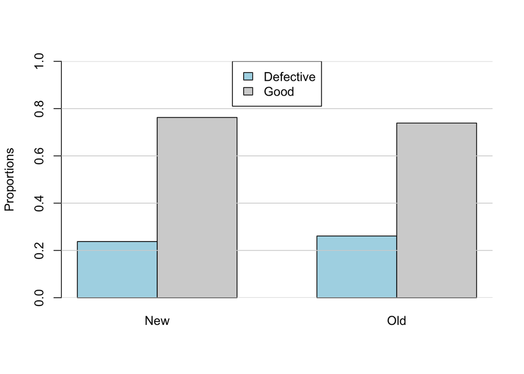

```r
x <- matrix(c(76/320, 244/320, 94/360, 266/360), ncol = 2, nrow = 2)
barplot(x, beside=TRUE, ylim = c(0, 1), names.arg = c('New', 'Old'), ylab = 'Proportions', col = c("lightblue", "lightgray"))
abline(h = c(0, 0.2, 0.4, 0.6, 0.8, 1), col = "lightgray")
legend("top", legend = c("Defective", "Good"), fill = c("lightblue", "lightgray"))
```

**Book Problem Set 10.6 #2** A random sample of 220 female and 210 male coffee drinkers were questioned. The result was that 71 of the women and 58 of the men indicated a preference for decaffeinated coffee. Do these data establish, at the 5 percent level of significance, that the proportion of female coffee drinkers who prefer decaffeinated coffee differs from the corresponding proportion for men?

### Compare Two Means

#### Independent Samples

The following *R* command performS hypothesis tests to compare two population means.

- x is the a sample from the first population.
- y is the a sample from the second population.
- Set `var.equal = TRUE` if the variance in the two populations are believed to be equal. Otherwise, set it to FALSE.

```r
t.test(x, y, alternative = , var.equal = )
```

**Example 1.**[^1] Suppose the recovery time for patients taking a new drug is measured (in days). A placebo group is also used to avoid the placebo effect. The data are as follows

- With drug: 15 10 13 7 9 8 21 9 14 8
- Placebo: 15 14 12 8 14 7 16 10 15 12

Does the drug shorten the recovery time?

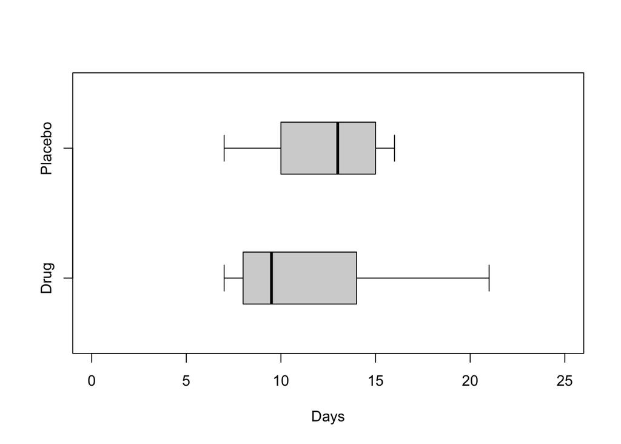

```r
x = c(15, 10, 13, 7, 9, 8, 21, 9, 14, 8)
y = c(15, 14, 12, 8, 14, 7, 16, 10, 15, 12)
boxplot(x, y, names = c("Drug", "Placebo"), xlab = "Days", ylim = c(0, 25),
        horizontal = TRUE, whisklty = 1, boxwex = 0.4)
```

#### Matched Pair

```r
t.test(x, y, paired = TRUE)
```

**Example 2.** In order to promote fairness in grading, each application was graded twice by different graders. Based on the grades, can we see if there is a difference between the two graders? The data is

- Grader 1: 3 0 5 2 5 5 5 4 4 5
- Grader 2: 2 1 4 1 4 3 3 2 3 5
[^1]: simpleR – Using R for Introductory Statistics by John Verzani.